# Capstone Project

Capstone Project

Author

Silvan Beekman

Published

June 6, 2024

# Introduction

This report is written in the context of the RBTL course, where the goal was to get hands on experience with gathering, cleaning and analysing data for a study. We are trying to understand waste and more specifically waste management. As everyone knows, we should recycle as much as possible, but current effort are just not enough Kibria et al. (2023) The idea for the study came across as a coincidence, because I noticed that my flat-mate uses a recycling app and I have never heard of one beforehand. According to Johansson (2016) the most important factors that help increase recycling are, well-designed infrastructure for recycling, specific recycling knowledge and general understanding of environmental aspects. Those could all be covered by an app. Another study explores how gamification of recycling can increase recyling rate, also something that can be achieved through an app Helmefalk and Rosenlund (2020). Therefore the goal of the study is to understand who the people are that use recycling apps and why people aren’t using them yet.

# Method

The data was gathered using a Google form designed with relevant questions to gain inshights into the respondents recycling behavior, general app usage, and experiences with recycling apps. Initially, I interviewed my friends during a morning stud session at a study place. I informed all participants about the study’s purpose and ensured that it is anonymous. This setting (study-place) provided the opportunity to engage with other students present in this room. Therefore the data collection process was more efficient and productive than anticipated.

# Result

## Demographic

First I wanted to understand who participated, by analysing age and gender.

```r
table_age <- capstone |>
  group_by(Age) |>
  summarise(n()) |> filter(!is.na(Age))

table_age |>
  gt() |>
  tab_header(title = "Age of survey paricipants") |>
  cols_label(Age = "Age", 'n()' = "Number of data")
```

Table 1: Number of answers by age

Age of survey paricipants

| Age | Number of data |
| --- | --- |
| 18-25 | 21 |
| 26-35 | 7 |

Table 1 shows not surprisingly that most people were between 18-25 years old, as most students are.

```r
table_gender <- capstone |>
  group_by(Gender) |>
  summarise(n()) |> filter(!is.na(Gender))

table_gender |>
    gt() |>
    tab_header(title = "Gender of survey participants") |>
    cols_label(Gender = "Gender", 'n()' = "Number of participants")
```

Table 2: Number of answers from male and female

Gender of survey participants

| Gender | Number of participants |
| --- | --- |
| Female | 12 |
| Male | 16 |

In Table 2 we see that slightly more men were interviewed than women. However at ETH the ratio of men/women is at the moment not fifty-fifty, but there are rather more men, so this is also an expected result.

```r
# combine table
combined_table <- capstone  |>
  group_by(Gender, Age) |>
  summarise(Number_of_participants = n())  |>
  filter(!is.na(Gender) & !is.na(Age))


combined_table  |>
  gt()  |>
  tab_header(title = "Survey Participants by Gender and Age --> maybe add amount of people you use the apps")  |>
  cols_label(Gender = "Gender",
             Age = "Age",
             Number_of_participants = "Number of participants")
```

Table 3: Overview of answers by demographic

| Age | Number of participants |
| --- | --- |
| Female |  |
| 18-25 | 9 |
| 26-35 | 3 |
| Male |  |
| 18-25 | 12 |
| 26-35 | 4 |

## Recycling app-users:

### Digital proficiency

Next I analyzed the people who said they are using recycling apps.

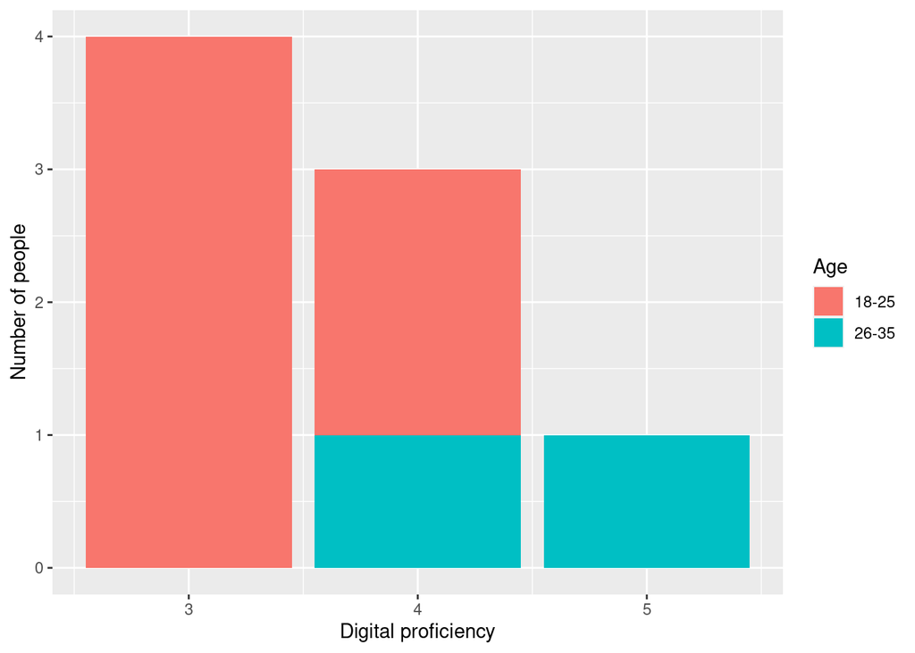

```r
count <- app_user |>
  count(digital_proficiency, Age)

digital_proficiencyvis <- ggplot(data = count,
       mapping = aes(x = digital_proficiency,
                     y = n,
                     fill = Age)) +
  geom_col() +
  labs(x = "Digital proficiency",
      y = "Number of people")
print(digital_proficiencyvis)
```

Figure 1 shows, that on a score of 1-5, people who use recycling apps give themselves scores equal or above 3 in digital proficiency. This means, that people using such apps, think that they are digitally proficient.

### Frequency of apps used daily

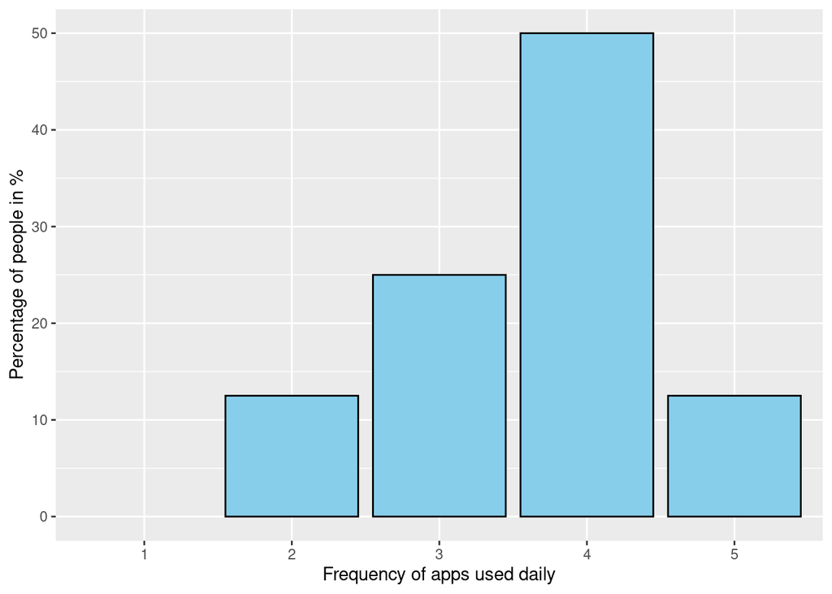

Figure 2: Reported frequency for usage of apps for daily tasks

```r
app_user$daily_apps <- factor(app_user$daily_apps, levels = 1:5)
#display in percentage
app_percent <- app_user  |>
  count(daily_apps)  |>
  mutate(apper = n / sum(n) * 100)


frequency_vis <- ggplot(data = app_percent,
       mapping = aes(x = daily_apps,
                     y = apper)) +
       geom_bar(stat = "identity", fill = "skyblue", color = "black") +
       labs(x = "Frequency of apps used daily",
            y = "Percentage of people in %") +
      scale_x_discrete(drop = FALSE)
print(frequency_vis)
```

Next, Figure 2 shows the usage of apps for daily tasks, for people using recycling apps. Here the scores are again predominantly in the higher half. So people using recycling apps, are also people who usually use apps for other daily tasks (i.e. Calender, Reminders, Shopping-lists, etc.).

## Non-users of recycling apps

### Recycling behaviour

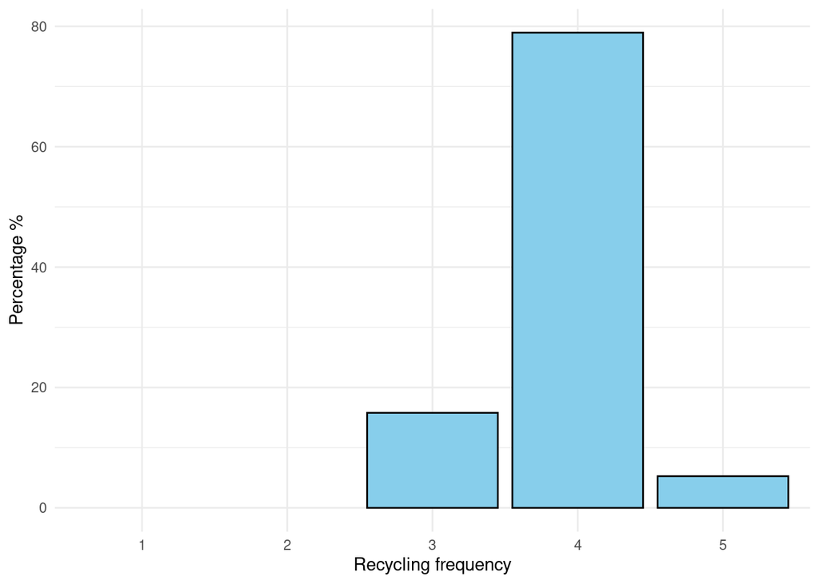

Figure 3: How frequent on a scale of 1-5 do people recycle

```r
#making sure that all numbers from 1-5 are shown
not_use$recycling <- factor(not_use$recycling, levels = 1:5)

#display in percentage
proportions <- not_use  |>
  count(recycling)  |>
  mutate(prop = n / sum(n) * 100)

recycling_vis <- ggplot(data = proportions,
       mapping = aes(x = recycling, y = prop)) +
  geom_bar(stat = "identity", fill = "skyblue", color = "black") +
  scale_x_discrete(drop = FALSE) +
  labs(x = "Recycling frequency", y = "Percentage %") +
  theme_minimal()
print(recycling_vis)
```

Figure 3 above shows the recycling behaviour of people who don’t use recycling apps. Most people opted to give themselves a score of 4 out 5 in frequency of recylcing. Here no one gave a score below 3.

### Reasons

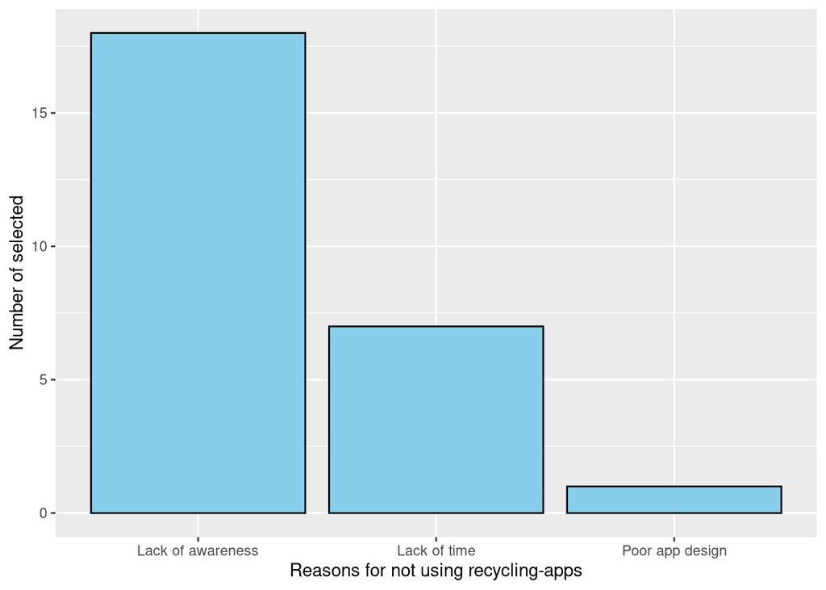

Figure 4: Reasons why people don’t use recycling-apps

```r
ggplot(data = reasons_against,
       mapping = aes(x = reason,
                     y = count)) +
      geom_bar(stat = "identity", fill = "skyblue", color = "black") +
      labs(x = "Reasons for not using recycling-apps",
           y = "Number of selected")
```

When asked for the possible reasons as to why they are not using recycling-apps, almost everyone said they wouldn’t know about these apps. Followed by the lack of time, with checking and interacting with an additional app everyday. One person who has tried recycling apps, said that the design of the app was too poor, to continue using it. This is visualised above Figure 4.

# Conclusion

The small study provided interesting insight into the user and especially non-users of recycling apps:

Recycling-app users:

- Have a high digital proficiency
- Enjoy using apps to help keep track of every day activities

Non-users of recycling-apps:

- Are people who recycle often
- Have never heard of such an app and therefore never considered using one

For developers of recycling apps it might be an interesting insight, that most people who don’t use such an app are not aware of their existence. Maybe also the marketing or design of the app should be for people with less digital proficiency, by taking a human-centered design approach.

## References

Helmefalk, Miralem, and Joacim Rosenlund. 2020. “Make Waste Fun Again! A Gamification Approach to Recycling.” In *Interactivity, Game Creation, Design, Learning, and Innovation*, edited by Anthony Brooks and Eva Irene Brooks, 328:415–26. Cham: Springer International Publishing. https://doi.org/10.1007/978-3-030-53294-9_30.

Johansson, K. 2016. “Understanding Recycling Behavior: A Study of Motivational Factors Behind Waste Recycling.” In *WASTE MANAGEMENT 2016*, 401–14. Valencia, Spain. https://doi.org/10.2495/WM160361.

Kibria, Md. Golam, Nahid Imtiaz Masuk, Rafat Safayet, Huy Quoc Nguyen, and Monjur Mourshed. 2023. “Plastic Waste: Challenges and Opportunities to Mitigate Pollution and Effective Management.” *International Journal of Environmental Research* 17 (1): 20. https://doi.org/10.1007/s41742-023-00507-z.